# R: Sequence alignment and Visualization Tutorial

Jason Lubega

31.Jan.2025

─── ⋆⋅☆⋅⋆ ───

### **Introduction**

The Needleman–Wunsch algorithm is an algorithm used in bioinformatics to align protein or nucleotide sequences. It was one of the first applications of dynamic programming to compare biological sequences. The algorithm was developed by Saul B. Needleman and Christian D. Wunsch and published in 1970

In this practice we are going to develop the Needleman–Wunsch algorithm in R. Our program, given two sequences, should provide the Needleman–Wunsch pairwise sequence alignment matrix, like this

**The figure below shows an example output of this algorithm**

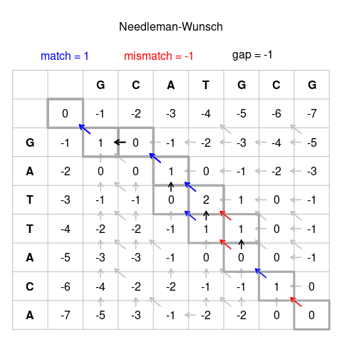

─── ⋆⋅☆⋅⋆ ───

### **Let’s start:**

Given these two sequences:

```r
sequence_1 <- c("G","C","A","T","G","C","G")
sequence_2 <- c("G","A","T","T","A","C","A")
```

We need to:

##### **1. Construct an empty matrix that allow initialization values for rows and columns. Something like this:**

```r
our_algo <- matrix(nrow = length(sequence_2)+1, ncol = length(sequence_1)+1,dimnames = list(c("ini",sequence_2),c("ini",sequence_1)) )
c <- colnames(our_algo)
r <- rownames(our_algo)

our_algo
```

```
    ini  G  C  A  T  G  C  G
ini  NA NA NA NA NA NA NA NA
G    NA NA NA NA NA NA NA NA
A    NA NA NA NA NA NA NA NA
T    NA NA NA NA NA NA NA NA
T    NA NA NA NA NA NA NA NA
A    NA NA NA NA NA NA NA NA
C    NA NA NA NA NA NA NA NA
A    NA NA NA NA NA NA NA NA
```

##### **2. Define the scoring system**

If you remember, we will fill the pairwise matrix according to the following strategy:

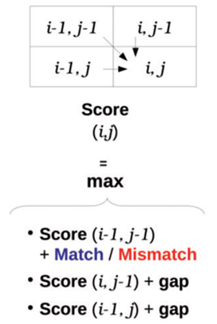

Where the (Penalties) values of match, mismatch and gap will be:

• Match: +1

• Mismatch: -1

• Gap: -1

##### **3. Fill the matrix with the initialization values**

We are going to give the following initialization values for rows and columns. Giving a higher penalization as more far you are from the beginning of the sequence.

```r
our_algo[1,] <- c(0:-7)
our_algo[,1] <- c(0:-7)

our_algo
```

```
    ini  G  C  A  T  G  C  G
ini   0 -1 -2 -3 -4 -5 -6 -7
G    -1 NA NA NA NA NA NA NA
A    -2 NA NA NA NA NA NA NA
T    -3 NA NA NA NA NA NA NA
T    -4 NA NA NA NA NA NA NA
A    -5 NA NA NA NA NA NA NA
C    -6 NA NA NA NA NA NA NA
A    -7 NA NA NA NA NA NA NA
```

##### **4. Fill the matrix following the system score defined.**

For each position of the matrix we need to compute the best score according to Needlman-Wunsch algorithm and store the value.

The output matrix must look like this:

```r
for (j in 2:ncol(our_algo)) {
  for (i in 2:nrow(our_algo)) {
    if(c[j]==r[i]){ #Match
      d <- our_algo[i-1,j-1]+1

    }

    else{ #Mismatch
      d <- our_algo[i-1,j-1]-1
    }
    s <- our_algo[i-1,j]-1
    t <- our_algo[i,j-1]-1
    our_algo[i,j] <- max(d,s,t)

  }


}

our_algo
```

```
    ini  G  C  A  T  G  C  G
ini   0 -1 -2 -3 -4 -5 -6 -7
G    -1  1  0 -1 -2 -3 -4 -5
A    -2  0  0  1  0 -1 -2 -3
T    -3 -1 -1  0  2  1  0 -1
T    -4 -2 -2 -1  1  1  0 -1
A    -5 -3 -3 -1  0  0  0 -1
C    -6 -4 -2 -2 -1 -1  1  0
A    -7 -5 -3 -1 -2 -2  0  0
```

##### **5. Generate a function**.

One of the attractions of R is the large number of functions that exist to perform various procedures.

A function is a set of instructions that convert inputs into desired results (outputs). Parts of a function:

• *Inputs or arguments:* the information needed to perform the function process. • *Body:* instructions that transform the inputs into the desired outputs. • *Outputs:* results of the function.

Every function must have at least one result. If a function returns several types of objects, it is customary to organize them in a list that can handle the different types of objects.

Function definition:

```r
function_name <- function(var){
 #Do something
return(new_variable)
}
```

Now that we have the program that computes the Needlman-Wunsch algorithm, lets create a function, called **“my_NW_algorithm”**, in a way that, given two sequences, the matrix of Needlman-Wunsch alignment is computed.

Then, run the function with the following sequences:

```r
# CASE 1:
sequence_1 <- c("G","C","A","T","G","C","G")
sequence_2 <- c("G","A","T","T","A","C","A")
# CASE 2:
sequence_1 <- c("A","T","G","G","C","G","T")
sequence_2 <- c("A","T","G","A","G","T")
```

The way to run the function will be something like this:

```r
my_NW_algorithm(sequence_1,sequence_2)
```

─── ⋆⋅☆⋅⋆ ───

### **Creating *“my_NW_algorithm”* function**

```r
my_NW_algorithm <- function(sequence_2, sequence_1){

  our_algo <- matrix(nrow = length(sequence_2)+1, ncol = length(sequence_1)+1)

  c <- colnames(our_algo) <-  c("ini", sequence_1)
  r <- rownames(our_algo) <-   c("ini", sequence_2)


  our_algo[,1] <- c(0:-length(sequence_2))
  our_algo[1,] <- c(0:-length(sequence_1))

  for (j in 2:ncol(our_algo)) {
    for (i in 2:nrow(our_algo)) {
      if(c[j]==r[i]){ #Match
        d <- our_algo[i-1,j-1]+1

      }

      else{ #Mismatch
        d <- our_algo[i-1,j-1]-1
      }
      s <- our_algo[i-1,j]-1
      t <- our_algo[i,j-1]-1

      our_algo[i,j] <- max(d,s,t)

    }

  }

  return(our_algo)
}
```

**My developed function will work like this instead until I revise it.**

```r
my_NW_algorithm(sequence_2,sequence_1)
```

─── ⋆⋅☆⋅⋆ ───

### **Visualise the alignment**

Now that we have a function that can align two sequences via the needleman algorithm, **let us make visual representation of the alignment using any tool of choice.**

For this activity I chose to use the **heatmap()**.

*Heatmaps* use values to represent data and the higher the value, the more intense the color tone. We will therefore leverage this to represent an alignment by choosing the maximum values in each row.

To generate a heatmap, We will save our alignment as *blah*,

```r
blah <- my_NW_algorithm(sequence_2,sequence_1)
```

And then

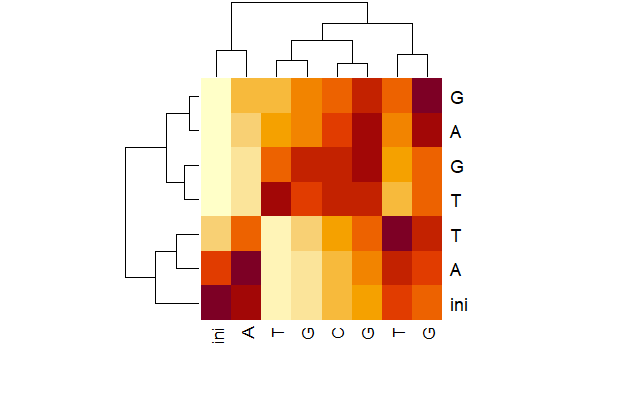

```r
heatmap(blah)
```

This plot has all values of the aligned matrix and therefore doesn’t give a sense of direction of the alignment.

> *The higher the value, the higher the color intensity.*

**Step 2:** We set out to modify the heatmap to only output “max values per row”. To this end we created a function to do that and saved the new matrix as max_row_mtrx.

In this function, we also assigned the value of 0 to fill the other values that were not the maximum in each row, so that only maximum values can be visualised on the heatmap.

```r
max_row_mtrx <- t(apply(blah, 1, function(row) {
  row[row != max(row)] <- 0 #replace with zero if not max
  return(row)
})) ##t() returns the matrix with the same dimensions.
max_row_mtrx
```

```
    ini A T G G C G T
ini   0 0 0 0 0 0 0 0
A     0 1 0 0 0 0 0 0
T     0 0 2 0 0 0 0 0
G     0 0 0 3 0 0 0 0
A     0 0 0 2 2 0 0 0
G     0 0 0 0 3 0 0 0
T     0 0 0 0 0 0 0 3
```

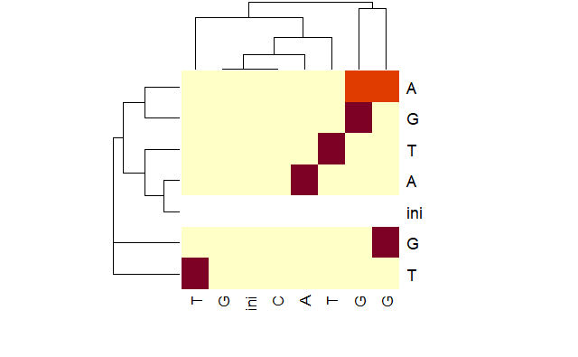

```r
heatmap(max_row_mtrx)
```

**Good Result! 😁 Almost there**

However, we observed that the colnames and rownames were reordered/clustered. Therefore, in the heatmap function, we stopped the reordering of the rows and columns with Rowv and Colv arguments as seen below:

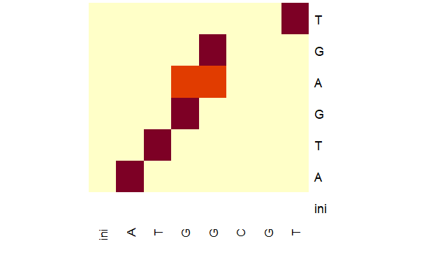

```r
heatmap(max_row_mtrx, Rowv = NA, Colv = NA)
```

```r
#No clustering/reordering rows and cols
```

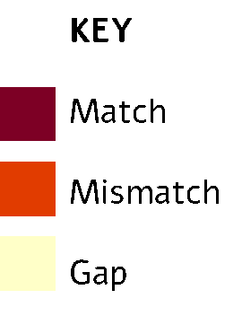

*KEY Alt text (Maroon = Match, Orange = Mismatch, Gap is obvious)*

##### **Therefore from the image of the alignment above our most likely alignment of the two sequences is:**

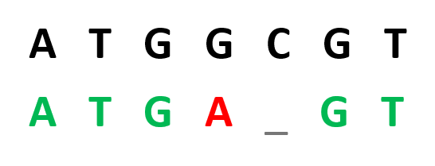

**Step 3:** Lastly, we allow the user to choose whether or not to display the graph. We give the Yes or No options as Y/N and record the answer. Then we simply nest our heatmap plotting code inside an if construct.

```r
ask <- readline(prompt="Would you like to graph your NW algorithm? (Y/N) ")
if (ask == "Y") {
    # plotting code
}
```

Find the full updated code here: https://github.com/lujason01/r-practice/blob/main/2seq_aligner_viz.R

#### Until next time ✌🏽

▂ ▃ ▄ ▅ ▆ ▇ █ █ ▇ ▆ ▅ ▄ ▃ ▂